# zlia62

Assignment-2A

Data preparation and exploration (35%)

1.1 Creating Spark Session (4%)

```python
from pyspark import SparkConf

master = "local[*]"
app_name = "FIT5202_Assignment-2A"
spark_conf = SparkConf().setMaster(master).setAppName(app_name)

from pyspark import SparkContext
from pyspark.sql import SparkSession

# Method 1: Using SparkSession
spark = SparkSession.builder.config(conf=spark_conf).getOrCreate()
sc = spark.sparkContext
sc.setLogLevel('ERROR')
```

```python
sc
```

**SparkContext**

[Spark UI](http://10.0.2.15:4040)

**Version**

`v3.0.0`

**Master**

`local[*]`

**AppName**

`FIT5202_Assignment-2A`

```python
# SET to all line print out
from IPython.core.interactiveshell import InteractiveShell
InteractiveShell.ast_node_interactivity = "all"
```

```python
from pyspark.sql.types import StructField
from pyspark.sql.types import StructType, IntegerType, StringType, DoubleType
import pandas as pd
from pandas.plotting import scatter_matrix
import seaborn as sn
import matplotlib.pyplot as plt
from pyspark.sql.functions import col, explode, array, lit
from pyspark.ml.feature import StringIndexer
from pyspark.ml.feature import OneHotEncoder
from pyspark.ml.feature import VectorAssembler
from pyspark.ml.classification import DecisionTreeClassifier
from pyspark.ml import Pipeline
from pyspark.ml.tuning import ParamGridBuilder, CrossValidator,CrossValidatorModel
from pyspark.ml.evaluation import BinaryClassificationEvaluator
from pyspark.ml.classification import GBTClassifier
from pyspark.ml.evaluation import MulticlassClassificationEvaluator
```

1.2 Loading the data (16%)

```python
ori_memory_schema = StructType([
    StructField("ts", IntegerType()),
    StructField("PID", IntegerType()),
    StructField("MINFLT", IntegerType()),
    StructField("MAJFLT", IntegerType()),
    StructField("VSTEXT", IntegerType()),
    StructField("VSIZE", DoubleType()),
    StructField("RSIZE", IntegerType()),
    StructField("VGROW", IntegerType()),
    StructField("RGROW", IntegerType()),
    StructField("MEM", DoubleType()),
    StructField("CMD", StringType()),
    StructField("attack", IntegerType()),
    StructField("type", StringType())])
```

```python
ori_memory_df = spark.read.csv("linux_memory_*", header=True, schema=ori_memory_schema)
ori_memory_df.show(5)
```

```
+----------+----+------+------+------+-----+-----+-----+-----+---+--------------+------+------+
|        ts| PID|MINFLT|MAJFLT|VSTEXT|VSIZE|RSIZE|VGROW|RGROW|MEM|           CMD|attack|  type|
+----------+----+------+------+------+-----+-----+-----+-----+---+--------------+------+------+
|1556743448|2123|     9|     0|   596|191.7| 4712|    0|    0|0.0|       apache2|     0|normal|
|1556743453|2925|     0|     0|   350|315.3| 4596|    0|    0|0.0|mission-contro|     0|normal|
|1556743458|1192|     2|     0|  1071|342.1| 4528|    0|    0|0.0|NetworkManager|     0|normal|
|1556743463|1404|     0|     0|    47|505.2| 3584|    0|    0|0.0|      whoopsie|     0|normal|
|1556743468|3238|     0|     0|    18|368.9| 3516|    0|    0|0.0|deja-dup-monit|     0|normal|
+----------+----+------+------+------+-----+-----+-----+-----+---+--------------+------+------+
only showing top 5 rows
```

However, since we are doing a classification machine learning model, therefore, we need to change the datatype for feature 'attaack' to string for further workflow,

```python
modi_memory_schema = StructType([
    StructField("ts", IntegerType()),
    StructField("PID", IntegerType()),
    StructField("MINFLT", IntegerType()),
    StructField("MAJFLT", IntegerType()),
    StructField("VSTEXT", IntegerType()),
    StructField("VSIZE", DoubleType()),
    StructField("RSIZE", IntegerType()),
    StructField("VGROW", IntegerType()),
    StructField("RGROW", IntegerType()),
    StructField("MEM", DoubleType()),
    StructField("CMD", StringType()),
    StructField("attack", StringType()),
    StructField("type", StringType())])
```

```python
memory_df = spark.read.csv("linux_memory_*", header=True, schema=modi_memory_schema)
memory_df.show(5)
```

```
+----------+----+------+------+------+-----+-----+-----+-----+---+--------------+------+------+
|        ts| PID|MINFLT|MAJFLT|VSTEXT|VSIZE|RSIZE|VGROW|RGROW|MEM|           CMD|attack|  type|
+----------+----+------+------+------+-----+-----+-----+-----+---+--------------+------+------+
|1556743448|2123|     9|     0|   596|191.7| 4712|    0|    0|0.0|       apache2|     0|normal|
|1556743453|2925|     0|     0|   350|315.3| 4596|    0|    0|0.0|mission-contro|     0|normal|
|1556743458|1192|     2|     0|  1071|342.1| 4528|    0|    0|0.0|NetworkManager|     0|normal|
|1556743463|1404|     0|     0|    47|505.2| 3584|    0|    0|0.0|      whoopsie|     0|normal|
|1556743468|3238|     0|     0|    18|368.9| 3516|    0|    0|0.0|deja-dup-monit|     0|normal|
+----------+----+------+------+------+-----+-----+-----+-----+---+--------------+------+------+
only showing top 5 rows
```

```python
print(f"Number of Count: {memory_df.count()}")
memory_df.printSchema()
```

```
Number of Count: 2000000
root
 |-- ts: integer (nullable = true)
 |-- PID: integer (nullable = true)
 |-- MINFLT: integer (nullable = true)
 |-- MAJFLT: integer (nullable = true)
 |-- VSTEXT: integer (nullable = true)
 |-- VSIZE: double (nullable = true)
 |-- RSIZE: integer (nullable = true)
 |-- VGROW: integer (nullable = true)
 |-- RGROW: integer (nullable = true)
 |-- MEM: double (nullable = true)
 |-- CMD: string (nullable = true)
 |-- attack: string (nullable = true)
 |-- type: string (nullable = true)
```

```python
#Check the shape of the dataframe
print((memory_df.count(), len(memory_df.columns)))
```

```
(2000000, 13)
```

```python
#Check for any null value for the dataframe
from pyspark.sql.functions import isnan, when, count, col
memory_df.select([count(when(isnan(c) | col(c).isNull(), c)).alias(c) for c in memory_df.columns]).show()
```

```
+---+---+------+------+------+-----+-----+-----+-----+---+---+------+----+
| ts|PID|MINFLT|MAJFLT|VSTEXT|VSIZE|RSIZE|VGROW|RGROW|MEM|CMD|attack|type|
+---+---+------+------+------+-----+-----+-----+-----+---+---+------+----+
|  0|  0|  9737|448868| 27907|    0|83545|50912|10294|  0|  0|     0|   0|
+---+---+------+------+------+-----+-----+-----+-----+---+---+------+----+
```

Since those columns with null value count might not fit the data type from the schema, therefore, we need to transfer the datatype for those columns, Besides, as we are doing a classification machine learning model, therefore, I have change the datatype for feature 'attaack' to string for further workflow, the following steps is to convert those null into 0 as spark consider them as null value which is not the case.

```python
memory_df = memory_df.fillna({'MINFLT':'0'})
memory_df = memory_df.fillna({'MAJFLT':'0'})
memory_df = memory_df.fillna({'VSTEXT':'0'})
memory_df = memory_df.fillna({'RSIZE':'0'})
memory_df = memory_df.fillna({'VGROW':'0'})
memory_df = memory_df.fillna({'RGROW':'0'})
```

```python
#Check for any null value for the dataframe
from pyspark.sql.functions import isnan, when, count, col
memory_df.select([count(when(isnan(c) | col(c).isNull(), c)).alias(c) for c in memory_df.columns]).show()
```

```
+---+---+------+------+------+-----+-----+-----+-----+---+---+------+----+
| ts|PID|MINFLT|MAJFLT|VSTEXT|VSIZE|RSIZE|VGROW|RGROW|MEM|CMD|attack|type|
+---+---+------+------+------+-----+-----+-----+-----+---+---+------+----+
|  0|  0|     0|     0|     0|    0|    0|    0|    0|  0|  0|     0|   0|
+---+---+------+------+------+-----+-----+-----+-----+---+---+------+----+
```

```python
ori_process_schema = StructType([
    StructField("ts", IntegerType()),
    StructField("PID", IntegerType()),
    StructField("TRUN", IntegerType()),
    StructField("TSLPI", IntegerType()),
    StructField("TSLPU", IntegerType()),
    StructField("POLI", StringType()),
    StructField("NICE", IntegerType()),
    StructField("PRI", IntegerType()),
    StructField("RTPR", IntegerType()),
    StructField("CPUNR", IntegerType()),
    StructField("Status", StringType()),
    StructField("EXC", IntegerType()),
    StructField("State", StringType()),
    StructField("CPU", DoubleType()),
    StructField("CMD", StringType()),
    StructField("attack", IntegerType()),
    StructField("type", StringType())
])
```

```python
ori_process_df = spark.read.csv("linux_process_*", header=True, schema= ori_process_schema)
ori_process_df.show(5)
```

```
+----------+----+----+-----+-----+----+----+---+----+-----+------+---+-----+----+-----------+------+------+
|        ts| PID|TRUN|TSLPI|TSLPU|POLI|NICE|PRI|RTPR|CPUNR|Status|EXC|State| CPU|        CMD|attack|  type|
+----------+----+----+-----+-----+----+----+---+----+-----+------+---+-----+----+-----------+------+------+
|1554218915|3257|   0|   23|    0|norm|   0|120|   0|    2|     N|  0|    S|0.13|Web-Content|     0|normal|
|1554218920|1442|   0|    1|    0|norm|   0|120|   0|    0|     N|  0|    S|0.09|       Xorg|     0|normal|
|1554218925|3197|   0|   63|    0|norm|   0|120|   0|    3|     N|  0|    S|0.06|    firefox|     0|normal|
|1554218930|2774|   0|    8|    0|norm|   0|120|   0|    0|     N|  0|    S|0.06|     compiz|     0|normal|
|1554218935|2797|   0|    5|    0|norm|   0|120|   0|    0|     N|  0|    S|0.04|   nautilus|     0|normal|
+----------+----+----+-----+-----+----+----+---+----+-----+------+---+-----+----+-----------+------+------+
only showing top 5 rows
```

However, since we are doing a classification machine learning model, therefore, we need to change the datatype for feature 'attaack' to string for further workflow,

```python
# Prepare process schema

modi_process_schema = StructType([
    StructField("ts", IntegerType()),
    StructField("PID", IntegerType()),
    StructField("TRUN", IntegerType()),
    StructField("TSLPI", IntegerType()),
    StructField("TSLPU", IntegerType()),
    StructField("POLI", StringType()),
    StructField("NICE", IntegerType()),
    StructField("PRI", IntegerType()),
    StructField("RTPR", IntegerType()),
    StructField("CPUNR", IntegerType()),
    StructField("Status", StringType()),
    StructField("EXC", IntegerType()),
    StructField("State", StringType()),
    StructField("CPU", DoubleType()),
    StructField("CMD", StringType()),
    StructField("attack", StringType()),
    StructField("type", StringType())
])
```

```python
process_df = spark.read.csv("linux_process_*", header=True, schema= modi_process_schema)
process_df.show(5)
```

```
+----------+----+----+-----+-----+----+----+---+----+-----+------+---+-----+----+-----------+------+------+
|        ts| PID|TRUN|TSLPI|TSLPU|POLI|NICE|PRI|RTPR|CPUNR|Status|EXC|State| CPU|        CMD|attack|  type|
+----------+----+----+-----+-----+----+----+---+----+-----+------+---+-----+----+-----------+------+------+
|1554218915|3257|   0|   23|    0|norm|   0|120|   0|    2|     N|  0|    S|0.13|Web-Content|     0|normal|
|1554218920|1442|   0|    1|    0|norm|   0|120|   0|    0|     N|  0|    S|0.09|       Xorg|     0|normal|
|1554218925|3197|   0|   63|    0|norm|   0|120|   0|    3|     N|  0|    S|0.06|    firefox|     0|normal|
|1554218930|2774|   0|    8|    0|norm|   0|120|   0|    0|     N|  0|    S|0.06|     compiz|     0|normal|
|1554218935|2797|   0|    5|    0|norm|   0|120|   0|    0|     N|  0|    S|0.04|   nautilus|     0|normal|
+----------+----+----+-----+-----+----+----+---+----+-----+------+---+-----+----+-----------+------+------+
only showing top 5 rows
```

```python
print(f"Number of Count: {process_df.count()}")
process_df.printSchema()
```

```
Number of Count: 1927968
root
 |-- ts: integer (nullable = true)
 |-- PID: integer (nullable = true)
 |-- TRUN: integer (nullable = true)
 |-- TSLPI: integer (nullable = true)
 |-- TSLPU: integer (nullable = true)
 |-- POLI: string (nullable = true)
 |-- NICE: integer (nullable = true)
 |-- PRI: integer (nullable = true)
 |-- RTPR: integer (nullable = true)
 |-- CPUNR: integer (nullable = true)
 |-- Status: string (nullable = true)
 |-- EXC: integer (nullable = true)
 |-- State: string (nullable = true)
 |-- CPU: double (nullable = true)
 |-- CMD: string (nullable = true)
 |-- attack: string (nullable = true)
 |-- type: string (nullable = true)
```

```python
#Check the shape of the dataframe
print((process_df.count(), len(process_df.columns)))
```

```
(1927968, 17)
```

```python
#Check for any null value for the dataframe
from pyspark.sql.functions import isnan, when, count, col
process_df.select([count(when(isnan(c) | col(c).isNull(), c)).alias(c) for c in process_df.columns]).show()
```

```
+---+---+----+-----+-----+----+----+---+----+-----+------+---+-----+---+---+------+----+
| ts|PID|TRUN|TSLPI|TSLPU|POLI|NICE|PRI|RTPR|CPUNR|Status|EXC|State|CPU|CMD|attack|type|
+---+---+----+-----+-----+----+----+---+----+-----+------+---+-----+---+---+------+----+
|  0|  0|   0|    0|    0|   0|   0|  0|   0|    0|     0|  0|    0|  0|  0|     0|   0|
+---+---+----+-----+-----+----+----+---+----+-----+------+---+-----+---+---+------+----+
```

1.3 Exploring the data (15%)

1. Show the count of attack and non-attack in each activity based on the column “attack”, then show the count of each kind of attack in process activity based on the column “type”.

```python
memory_df.groupby('attack').count().toPandas()
```

|  | attack | count |
| --- | --- | --- |
| 0 | 0 | 1794377 |
| 1 | 1 | 205623 |

```python
#Show the count of attack and non-attack in each activity based on the column “attack” where 1 stands for attack, 0 for non-attack

memory_df_attack = memory_df.filter(col("attack") == "1")
#print(f"Number of Memory Attack Count: {memory_df_attack.count()}")
memory_df_nonattack = memory_df.filter(col("attack") == "0")
#print(f"Number of Memory Non-Attack Count: {memory_df_nonattack.count()}")

print(f"Percentage of memory attack over all activity: {memory_df_attack.count()/ memory_df.count()}")
print(f"Percentage of memory non-attack over all activity: {memory_df_nonattack.count()/ memory_df.count()}")
```

```
Percentage of memory attack over all activity: 0.1028115
Percentage of memory non-attack over all activity: 0.8971885
```

```python
process_df.groupby('attack').count().toPandas()
```

|  | attack | count |
| --- | --- | --- |
| 0 | 0 | 1636604 |
| 1 | 1 | 291364 |

```python
#Show the count of attack and non-attack in each activity based on the column “attack”
process_df_attack = process_df.filter(col("attack") == "1")
#print(f"Number of Process Attack Count: {process_df_attack.count()}")
process_df_nonattack = process_df.filter(col("attack") == "0")
#print(f"Number of Process Non-Attack Count: {process_df_nonattack.count()}")

print(f"Percentage of process attack over all activity: {process_df_attack.count()/ process_df.count()}")
print(f"Percentage of process non-attack over all activity: {process_df_nonattack.count()/ process_df.count()}")
```

```
Percentage of process attack over all activity: 0.1511249149363475
Percentage of process non-attack over all activity: 0.8488750850636525
```

```python
#show the count of each kind of attack in memory activity based on the column “type”
memory_df_group = memory_df.groupBy(col("type")).count().show()
```

```
+---------+-------+
|     type|  count|
+---------+-------+
| password|  26016|
|     ddos|  45689|
|   normal|1794377|
|     mitm|    112|
|injection|  58523|
|      dos|  75283|
+---------+-------+
```

```python
#show the count of each kind of attack in process activity based on the column “type”
process_df_group = process_df.groupBy(col("type")).count().show()
```

```
+---------+-------+
|     type|  count|
+---------+-------+
|      xss|  17759|
| password|  51409|
| scanning|  38449|
|     ddos|  71603|
|   normal|1636604|
|     mitm|    112|
|injection|  41311|
|      dos|  70721|
+---------+-------+
```

As we can see from the percentage result calculated above, which clearly indicates that the the dataset are highly inbalance, therefore, we should apply some kind of class rebalance strategy to the dataset. With figure that Percentage of memory attack over all activity: 0.1028115 and Percentage of process attack over all activity: 0.1511249149363475. In order to help us improve the performance of the machine learning model, rebalnce dataset can give us normalize the dataset for futher implementation.

```python
# Filter out the require columns for memory activity
memory_numCols = [field for (field, dataType) in memory_df.dtypes if ((dataType == "int") & (field != "attack") | (dataType == "double"))]
memory_catCols = [field for (field, dataType) in memory_df.dtypes if ((dataType == "string") & (field != "type")& (field != "attack"))]
```

```python
memory_numeric_summary = memory_df.select(memory_numCols)
memory_numeric_summary.describe().toPandas().head()
```

|  | summary | ts | PID | MINFLT | MAJFLT | VSTEXT | VSIZE | RSIZE | VGROW | RGROW | MEM |
| --- | --- | --- | --- | --- | --- | --- | --- | --- | --- | --- | --- |
| 0 | count | 2000000 | 2000000 | 2000000 | 2000000 | 2000000 | 2000000 | 2000000 | 2000000 | 2000000 | 2000000 |
| 1 | mean | 1.55624581707609E9 | 4999.360446 | 402.544344 | 1036.372826 | 2799.038894 | 4496.419966445937 | 6108.720511 | 183.080485 | 483.1658505 | 0.003385165000012971 |
| 2 | stddev | 984463.3682796999 | 4887.313351921402 | 17144.014252399495 | 5187.488206752466 | 8176.947916585402 | 9046.338093398834 | 15886.889729100996 | 2924.253229197268 | 1491.478712241447 | 0.010943425779985772 |
| 3 | min | 1554216855 | 1007 | 0 | 0 | 0 | 0.0 | -9728 | -8652 | 0 | 0.0 |
| 4 | max | 1558355716 | 53096 | 8050000 | 107776 | 99992 | 88040.0 | 99932 | 99684 | 98920 | 0.44 |

```python
memory_non_numeric_summary = memory_df.groupBy(memory_catCols)

# Display non-numeric feature in memory activity with top 10 counts
memory_non_numeric_summary.count().sort(['count'], ascending=False).show(10)
```

```
+----------+------+
|       CMD| count|
+----------+------+
|      atop|325985|
|   apache2| 89761|
| jfsCommit| 81714|
|  vmtoolsd| 77871|
|      Xorg| 49981|
|  nautilus| 48356|
|irqbalance| 44387|
|    compiz| 44356|
|  ostinato| 43024|
|     drone| 41392|
+----------+------+
only showing top 10 rows
```

```python
# Filter out the require columns for process activity
process_numCols = [field for (field, dataType) in process_df.dtypes if ((dataType == "int") | (dataType == "double") & (field != "attack"))]
process_catCols = [field for (field, dataType) in process_df.dtypes if ((dataType == "string") & (field != "type")& (field != "attack"))]
```

```python
# Display basic statistics for numeric feature in memory activity
process_numeric_summary = process_df.select(process_numCols)
process_numeric_summary.describe().toPandas().head()
```

|  | summary | ts | PID | TRUN | TSLPI | TSLPU | NICE | PRI | RTPR | CPUNR | EXC | CPU |
| --- | --- | --- | --- | --- | --- | --- | --- | --- | --- | --- | --- | --- |
| 0 | count | 1927968 | 1927968 | 1927968 | 1927968 | 1927968 | 1927968 | 1927968 | 1927968 | 1927968 | 1927968 | 1927968 |
| 1 | mean | 1.5563198311840394E9 | 5068.709770597852 | 0.0632287465352122 | 3.508334163222626 | 3.6100184235422994E-4 | 4.634469555511295 | 111.26826741937626 | 0.0 | 1.9210142491991569 | 0.030275398761805176 | 0.022385272992102183 |
| 2 | stddev | 771350.0248303566 | 4987.784329320465 | 0.2478258709041639 | 6.988459728531808 | 0.04421874419214536 | 8.403189864752136 | 22.62444506210303 | 0.0 | 1.5274047225902738 | 1.4619498567691969 | 0.13628943687183998 |
| 3 | min | 1554216855 | 1007 | 0 | 0 | 0 | 0 | 0 | 0 | 0 | 0 | 0.0 |
| 4 | max | 1557593017 | 53080 | 12 | 70 | 21 | 20 | 139 | 0 | 5 | 127 | 4.02 |

```python
# Group the dataframe via all string columns, 4 columns in this case
process_non_numeric_summary = process_df.groupBy(process_catCols)

# Display non-numeric feature in memory activity with top 10 counts
process_non_numeric_summary.count().sort(['count'], ascending=False).show(10)
```

```
+----+------+-----+--------------+------+
|POLI|Status|State|           CMD| count|
+----+------+-----+--------------+------+
|norm|     -|    S|          atop|330980|
|norm|     0|    S|       apache2|192479|
|norm|     -|    S|       apache2|107857|
|norm|     -|    S|      vmtoolsd| 95326|
|norm|     -|    R|          atop| 62883|
|norm|     -|    S|          Xorg| 55910|
|norm|     -|    S|      nautilus| 52287|
|norm|     -|    S|gnome-terminal| 40851|
|norm|     -|    S|        mysqld| 36427|
|norm|     0|    S|          atop| 35352|
+----+------+-----+--------------+------+
only showing top 10 rows
```

For each activity, present two plots worthy of presenting to the StopHacking company, describe your plots and discuss the findings from the plots

```python
m_numCols = [field for (field, dataType) in ori_memory_df.dtypes if ((dataType == "int") | (dataType == "double"))]
p_numCols = [field for (field, dataType) in ori_process_df.dtypes if ((dataType == "int") | (dataType == "double"))]
```

```python
memory_numeric_Pandas = ori_memory_df.select(m_numCols).toPandas()
```

```python
process_numeric_Pandas = ori_process_df.select(p_numCols).toPandas()
```

```python
memory_numeric_Pandas.var()
```

```
ts        9.691681e+11
PID       2.388583e+07
MINFLT    2.953544e+08
MAJFLT    3.429653e+07
VSTEXT    6.769621e+07
VSIZE     8.183623e+07
RSIZE     2.616983e+08
VGROW     8.773725e+06
RGROW     2.234804e+06
MEM       1.197586e-04
attack    9.224134e-02
dtype: float64
```

```python
process_numeric_Pandas.var()
```

```
ts        5.949809e+11
PID       2.487799e+07
TRUN      6.141766e-02
TSLPI     4.883857e+01
TSLPU     1.955297e-03
NICE      7.061360e+01
PRI       5.118655e+02
RTPR      0.000000e+00
CPUNR     2.332965e+00
EXC       2.137297e+00
CPU       1.857481e-02
attack    1.282862e-01
dtype: float64
```

Then, we look at the correlation between variable and target variable 'attack'

```python
memory_numeric_Pandas.corr()
```

|  | ts | PID | MINFLT | MAJFLT | VSTEXT | VSIZE | RSIZE | VGROW | RGROW | MEM | attack |
| --- | --- | --- | --- | --- | --- | --- | --- | --- | --- | --- | --- |
| ts | 1.000000 | -0.523585 | -0.004167 | 0.234210 | 0.207584 | -0.085328 | -0.040196 | 0.017800 | 0.315809 | 0.026300 | 0.037772 |
| PID | -0.523585 | 1.000000 | -0.005060 | -0.122656 | -0.173893 | -0.144374 | -0.182888 | 0.056859 | -0.175633 | -0.124017 | -0.096568 |
| MINFLT | -0.004167 | -0.005060 | 1.000000 | 0.002405 | -0.005286 | 0.027302 | -0.004382 | 0.013210 | 0.008901 | -0.002180 | -0.001882 |
| MAJFLT | 0.234210 | -0.122656 | 0.002405 | 1.000000 | 0.169837 | -0.133645 | -0.105933 | -0.014868 | 0.111342 | -0.078759 | 0.015932 |
| VSTEXT | 0.207584 | -0.173893 | -0.005286 | 0.169837 | 1.000000 | -0.161491 | -0.080073 | -0.012228 | 0.174899 | 0.041873 | 0.040638 |
| VSIZE | -0.085328 | -0.144374 | 0.027302 | -0.133645 | -0.161491 | 1.000000 | -0.125474 | 0.276581 | -0.142959 | -0.141592 | -0.000670 |
| RSIZE | -0.040196 | -0.182888 | -0.004382 | -0.105933 | -0.080073 | -0.125474 | 1.000000 | -0.013486 | -0.119820 | 0.556851 | 0.068170 |
| VGROW | 0.017800 | 0.056859 | 0.013210 | -0.014868 | -0.012228 | 0.276581 | -0.013486 | 1.000000 | 0.058963 | 0.008710 | 0.031921 |
| RGROW | 0.315809 | -0.175633 | 0.008901 | 0.111342 | 0.174899 | -0.142959 | -0.119820 | 0.058963 | 1.000000 | -0.016887 | -0.016152 |
| MEM | 0.026300 | -0.124017 | -0.002180 | -0.078759 | 0.041873 | -0.141592 | 0.556851 | 0.008710 | -0.016887 | 1.000000 | 0.011157 |
| attack | 0.037772 | -0.096568 | -0.001882 | 0.015932 | 0.040638 | -0.000670 | 0.068170 | 0.031921 | -0.016152 | 0.011157 | 1.000000 |

```python
process_numeric_Pandas.corr()
```

|  | ts | PID | TRUN | TSLPI | TSLPU | NICE | PRI | RTPR | CPUNR | EXC | CPU | attack |
| --- | --- | --- | --- | --- | --- | --- | --- | --- | --- | --- | --- | --- |
| ts | 1.000000 | 0.058500 | -0.036179 | 0.022444 | -0.001144 | -0.058517 | 0.085286 | NaN | 0.175746 | -0.007863 | -0.058824 | 0.023795 |
| PID | 0.058500 | 1.000000 | -0.064925 | -0.179193 | -0.000047 | -0.133653 | -0.142430 | NaN | 0.075402 | 0.015794 | -0.043111 | -0.053643 |
| TRUN | -0.036179 | -0.064925 | 1.000000 | 0.011755 | 0.000568 | 0.232263 | -0.039898 | NaN | -0.042470 | -0.005284 | 0.518717 | -0.008617 |
| TSLPI | 0.022444 | -0.179193 | 0.011755 | 1.000000 | -0.000878 | -0.208580 | 0.169082 | NaN | 0.073798 | -0.010396 | 0.145321 | 0.051909 |
| TSLPU | -0.001144 | -0.000047 | 0.000568 | -0.000878 | 1.000000 | -0.003788 | 0.002898 | NaN | 0.001436 | -0.000169 | 0.006932 | 0.005561 |
| NICE | -0.058517 | -0.133653 | 0.232263 | -0.208580 | -0.003788 | 1.000000 | -0.270357 | NaN | -0.082966 | -0.011421 | -0.060272 | -0.068105 |
| PRI | 0.085286 | -0.142430 | -0.039898 | 0.169082 | 0.002898 | -0.270357 | 1.000000 | NaN | 0.260426 | -0.101848 | 0.050837 | 0.001189 |
| RTPR | NaN | NaN | NaN | NaN | NaN | NaN | NaN | NaN | NaN | NaN | NaN | NaN |
| CPUNR | 0.175746 | 0.075402 | -0.042470 | 0.073798 | 0.001436 | -0.082966 | 0.260426 | NaN | 1.000000 | -0.026046 | -0.047501 | 0.003401 |
| EXC | -0.007863 | 0.015794 | -0.005284 | -0.010396 | -0.000169 | -0.011421 | -0.101848 | NaN | -0.026046 | 1.000000 | -0.003224 | -0.000836 |
| CPU | -0.058824 | -0.043111 | 0.518717 | 0.145321 | 0.006932 | -0.060272 | 0.050837 | NaN | -0.047501 | -0.003224 | 1.000000 | -0.028798 |
| attack | 0.023795 | -0.053643 | -0.008617 | 0.051909 | 0.005561 | -0.068105 | 0.001189 | NaN | 0.003401 | -0.000836 | -0.028798 | 1.000000 |

```python
abs(memory_numeric_Pandas.corr()["attack"])
```

```
ts        0.037772
PID       0.096568
MINFLT    0.001882
MAJFLT    0.015932
VSTEXT    0.040638
VSIZE     0.000670
RSIZE     0.068170
VGROW     0.031921
RGROW     0.016152
MEM       0.011157
attack    1.000000
Name: attack, dtype: float64
```

Base on the correltaion between numeric variable and target variable 'attack', variable with close to 0 correlation should be consider irrelvant for further machine learning model.

```python
abs(process_numeric_Pandas.corr()["attack"])
```

```
ts        0.023795
PID       0.053643
TRUN      0.008617
TSLPI     0.051909
TSLPU     0.005561
NICE      0.068105
PRI       0.001189
RTPR           NaN
CPUNR     0.003401
EXC       0.000836
CPU       0.028798
attack    1.000000
Name: attack, dtype: float64
```

Base on the correltaion between numeric variable and target variable 'attack', variable with close to 0 correlation should be consider irrelvant for further machine learning model.

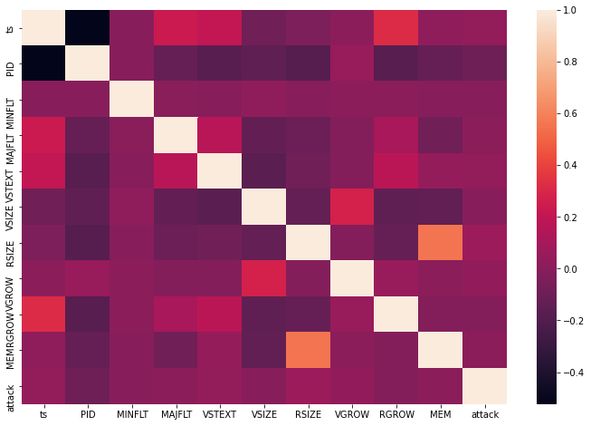

```python
fig_dims = (12, 8)
fig, ax = plt.subplots(figsize=fig_dims)
sn.heatmap(memory_numeric_Pandas.corr(), ax=ax)
plt.show()
```

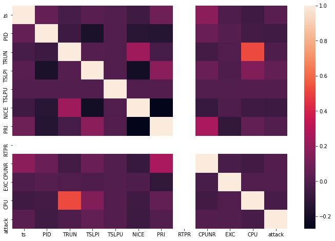

```python
fig_dims = (12, 8)
fig, ax = plt.subplots(figsize=fig_dims)
sn.heatmap(process_numeric_Pandas.corr(), ax=ax)
plt.show()
```

1. Featurextraction and ML training (55%)

2.1 Preparing the training data and testing data (4%)

```python
# Split the dataset into 8:2 ratio for train and test set for memory activity
memory_train, memory_test = memory_df.randomSplit([.8, .2], seed=42)
print(f"""There are {memory_train.count()} rows in the memory training set, and {memory_test.count()} in the memory test set""")
```

```
There are 1600486 rows in the memory training set, and 399514 in the memory test set
```

```python
# Split the dataset into 8:2 ratio for train and test set for memory activity
process_train, process_test = process_df.randomSplit([.8, .2], seed=42)
print(f"""There are {process_train.count()} rows in the process training set, and {process_test.count()} in the process test set""")
```

```
There are 1542780 rows in the process training set, and 385188 in the process test set
```

undersampling the non-attack event for both activity

```python
# Undersampl for memory activity to 1:2 ratio
# label 0 as non-attack event, and label 1 as attack event
memory_major_df = memory_df.filter(col("attack") == '0')
memory_minor_df = memory_df.filter(col("attack") == '1')
```

```python
m_sampled_majority_df = memory_major_df.sample(False, 0.23)
m_combined_df_2 = m_sampled_majority_df.unionAll(memory_minor_df)
m_combined_df_2.count()
```

```
618016
```

```python
m_combined_df_2.groupby('attack').count().toPandas()
```

|  | attack | count |
| --- | --- | --- |
| 0 | 0 | 412393 |
| 1 | 1 | 205623 |

```python
# Undersampl for process activity to 1:2 ratio
# label 0 as non-attack event, and label 1 as attack event
process_major_df = process_df.filter(col("attack") == '0')
process_minor_df = process_df.filter(col("attack") == '1')
```

```python
p_sampled_majority_df = process_major_df.sample(False, 0.36)
p_combined_df_2 = p_sampled_majority_df.unionAll(process_minor_df)
p_combined_df_2.count()
```

```
880762
```

```python
p_combined_df_2.groupby('attack').count().toPandas()
```

|  | attack | count |
| --- | --- | --- |
| 0 | 0 | 589398 |
| 1 | 1 | 291364 |

2.2 Preparing features, labels and models (16%)

In order to perfrom a classification model, we need some form of feature engineering. First, we drop the irrelvant columns and get the new dataset with relevant columns. Then we split the numer columns and category columns into 2 seperate variable. And mark our traget variable as 'attack' and then we apply stringIndexer, OneHotEncoder and vector Assembler to combine the categoric and numeric columne into our feature. after that, we create our algorithms on decision tree or GBTClassifier and fit all the steps into a pipeline.

And finally, we pass the train dataset into the pipeline to train the model and further test our test dataset to validate the performance.

```python
workclass = {'norm':0,'btch':1,'idle':2,'fifo':3,'rr':4,'0':5,'-':6}

def mapr(dict_key):
    return workclass[dict_key]
```

Building Imbalanced memory model for classification

```python
m_drop_list = ['MEM', 'VSIZE', 'MINFLT']

memory_df = memory_df.select([column for column in memory_df.columns if column not in m_drop_list])

m_numericInputCols = [field for (field, dataType) in memory_df.dtypes if ((dataType == "int") | (dataType == "double") & (field != "attack"))]
m_categoryInputCols = [field for (field, dataType) in memory_df.dtypes if ((dataType == "string") & (field != "attack"))]
m_categoryOutputCol = 'attack'
m_categoryCols = m_categoryInputCols+[m_categoryOutputCol]

m_outputCols=[f'{x}_index' for x in m_categoryInputCols]
m_outputCols.append('label')
m_inputIndexer = StringIndexer(inputCols=m_categoryCols, outputCols=m_outputCols)

m_inputCols_OHE = [x for x in m_outputCols if x!='label']
m_outputCols_OHE = [f'{x}_vec' for x in m_categoryInputCols]
m_encoder = OneHotEncoder(inputCols=m_inputCols_OHE,outputCols=m_outputCols_OHE)

m_inputCols=m_outputCols_OHE
m_assemblerInputs = m_outputCols_OHE + m_numericInputCols
m_assembler = VectorAssembler(inputCols = m_assemblerInputs, outputCol="features")

m_dt = DecisionTreeClassifier(featuresCol = 'features', labelCol = 'label', maxDepth = 3)

stage_1 = m_inputIndexer
stage_2 = m_encoder
stage_3 = m_assembler
stage_4 = m_dt

stages = [stage_1,stage_2,stage_3,stage_4]
```

```python
pipeline = Pipeline(stages = stages)
pipelineModel = pipeline.fit(memory_train)
predictions = pipelineModel.transform(memory_test)
```

```python
m_gb = GBTClassifier(labelCol = 'label', featuresCol = 'features')

stage_1 = m_inputIndexer
stage_2 = m_encoder
stage_3 = m_assembler
stage_4 = m_gb

stages = [stage_1,stage_2,stage_3,stage_4]
```

```python
pipeline = Pipeline(stages = stages)
pipelineModel = pipeline.fit(memory_train)
predictions = pipelineModel.transform(memory_test)
```

Building Imbalanced process model for classification

```python
p_drop_list = ['CPU', 'TRUN', 'TSLPU', 'PRI', 'RTPR', 'CPUNR', 'EXC']
p_combined_df_2 = process_df.select([column for column in process_df.columns if column not in p_drop_list])

p_numericInputCols = [field for (field, dataType) in p_combined_df_2.dtypes if ((dataType == "int") | (dataType == "double") & (field != "attack"))]
p_categoryInputCols = [field for (field, dataType) in p_combined_df_2.dtypes if ((dataType == "string") & (field != "attack"))]

p_categoryOutputCol = 'attack'
p_categoryCols = p_categoryInputCols+[p_categoryOutputCol]

p_outputCols=[f'{x}_index' for x in p_categoryInputCols]
p_outputCols.append('label')
p_inputIndexer = StringIndexer(inputCols=p_categoryCols, outputCols=p_outputCols)

p_inputCols_OHE = [x for x in p_outputCols if x!='label']
p_outputCols_OHE = [f'{x}_vec' for x in p_categoryInputCols]
p_encoder = OneHotEncoder(inputCols=p_inputCols_OHE,outputCols=p_outputCols_OHE)

p_inputCols=p_outputCols_OHE
p_assemblerInputs = p_outputCols_OHE + p_numericInputCols
p_assembler = VectorAssembler(inputCols = p_assemblerInputs, outputCol="features")

p_dt = DecisionTreeClassifier(featuresCol = 'features', labelCol = 'label', maxDepth = 3)

stage_1 = p_inputIndexer
stage_2 = p_encoder
stage_3 = p_assembler
stage_4 = p_dt

stages = [stage_1,stage_2,stage_3,stage_4]
```

[output not shown]

```python
pipeline = Pipeline(stages = stages)
pipelineModel = pipeline.fit(process_train)
predictions = pipelineModel.transform(process_test)
```

```python
p_gb = GBTClassifier(labelCol = 'label', featuresCol = 'features')

stage_1 = p_inputIndexer
stage_2 = p_encoder
stage_3 = p_assembler
stage_4 = p_gb

stages = [stage_1,stage_2,stage_3,stage_4]
```

```python
pipeline = Pipeline(stages = stages)
pipelineModel = pipeline.fit(process_train)
predictions = pipelineModel.transform(process_test)
```

2.3 Training and evaluating models (35%)

For each use case, use the corresponding ML Pipeline from previous step to train the models on the rebalanced training data from 2.1.2

```python
# Prepare test and train dataset based on rebalanced dataset
memory_train, memory_test = m_combined_df_2.randomSplit([.8, .2], seed=42)
print(f"""There are {memory_train.count()} rows in the memory training set, and {memory_test.count()} in the memory test set""")
```

```
There are 494236 rows in the memory training set, and 123780 in the memory test set
```

```python
# Split the dataset into 8:2 ratio for train and test set for memory activity
process_train, process_test = p_combined_df_2.randomSplit([.8, .2], seed=42)
print(f"""There are {process_train.count()} rows in the process training set, and {process_test.count()} in the process test set""")
```

[output not shown]

Create Transformers / Estimators for transforming / assembling the features

```python
m_drop_list = ['MEM', 'VSIZE', 'MINFLT']

m_combined_df_2 = m_combined_df_2.select([column for column in m_combined_df_2.columns if column not in m_drop_list])
```

```python
# Filter out the require columns for process activity
m_numericInputCols = [field for (field, dataType) in m_combined_df_2.dtypes if ((dataType == "int") | (dataType == "double") & (field != "attack"))]
m_categoryInputCols = [field for (field, dataType) in m_combined_df_2.dtypes if ((dataType == "string") & (field != "attack"))]
m_numericInputCols
m_categoryInputCols
```

```
['ts', 'PID', 'MAJFLT', 'VSTEXT', 'RSIZE', 'VGROW', 'RGROW']
```

```
['CMD', 'type']
```

```python
p_drop_list = ['CPU', 'TRUN', 'TSLPU', 'PRI', 'RTPR', 'CPUNR', 'EXC']
p_combined_df_2 = p_combined_df_2.select([column for column in p_combined_df_2.columns if column not in p_drop_list])
```

```python
p_combined_df_2.show(2)
```

```
+----------+----+-----+----+----+------+-----+-----------+------+------+
|        ts| PID|TSLPI|POLI|NICE|Status|State|        CMD|attack|  type|
+----------+----+-----+----+----+------+-----+-----------+------+------+
|1554218915|3257|   23|norm|   0|     N|    S|Web-Content|     0|normal|
|1554218920|1442|    1|norm|   0|     N|    S|       Xorg|     0|normal|
+----------+----+-----+----+----+------+-----+-----------+------+------+
only showing top 2 rows
```

```python
# Filter out the require columns for process activity
p_numericInputCols = [field for (field, dataType) in p_combined_df_2.dtypes if ((dataType == "int") | (dataType == "double") & (field != "attack"))]
p_categoryInputCols = [field for (field, dataType) in p_combined_df_2.dtypes if ((dataType == "string") & (field != "attack"))]
p_numericInputCols
p_categoryInputCols
```

```
['ts', 'PID', 'TSLPI', 'NICE']
```

```
['POLI', 'Status', 'State', 'CMD', 'type']
```

Prepare Estimators for Decision Tree and Gradient Boosted Tree model for each use case and include them into ML Pipelines for use case 1, 2

```python
from pyspark.ml.feature import StringIndexer
from pyspark.ml.feature import OneHotEncoder
from pyspark.ml.feature import VectorAssembler
from pyspark.ml.classification import DecisionTreeClassifier
from pyspark.ml import Pipeline
from pyspark.ml.classification import GBTClassifier
from pyspark.ml.evaluation import MulticlassClassificationEvaluator
from pyspark.ml.clustering import KMeans
```

```python
m_categoryOutputCol = 'attack'
m_categoryCols = m_categoryInputCols+[m_categoryOutputCol]
m_categoryCols
```

```
['CMD', 'type', 'attack']
```

```python
m_outputCols=[f'{x}_index' for x in m_categoryInputCols]
m_outputCols.append('label')
m_inputIndexer = StringIndexer(inputCols=m_categoryCols, outputCols=m_outputCols)
m_outputCols
m_inputIndexer
```

```
['CMD_index', 'type_index', 'label']
```

```
StringIndexer_dc04711f9b32
```

```python
m_inputCols_OHE = [x for x in m_outputCols if x!='label']
m_outputCols_OHE = [f'{x}_vec' for x in m_categoryInputCols]
m_encoder = OneHotEncoder(inputCols=m_inputCols_OHE,outputCols=m_outputCols_OHE)
m_outputCols_OHE
m_encoder
```

```
['CMD_vec', 'type_vec']
```

```
OneHotEncoder_813dc0daa4e0
```

```python
m_inputCols=m_outputCols_OHE
m_assemblerInputs = m_outputCols_OHE + m_numericInputCols
m_assembler = VectorAssembler(inputCols = m_assemblerInputs, outputCol="features")
m_assemblerInputs
m_assembler
```

```
['CMD_vec',
 'type_vec',
 'ts',
 'PID',
 'MAJFLT',
 'VSTEXT',
 'RSIZE',
 'VGROW',
 'RGROW']
```

```
VectorAssembler_0ba573657751
```

Decision Tree Classifier Model for memory activity

```python
m_dt = DecisionTreeClassifier(featuresCol = 'features', labelCol = 'label', maxDepth = 3)
```

```python
stage_1 = m_inputIndexer
stage_2 = m_encoder
stage_3 = m_assembler
stage_4 = m_dt

stages = [stage_1,stage_2,stage_3,stage_4]
```

```python
pipeline = Pipeline(stages = stages)
pipelineModel = pipeline.fit(memory_train)
predictions = pipelineModel.transform(memory_test)
```

```python
predictions.select('features','label','prediction').show()
```

```
+--------------------+-----+----------+
|            features|label|prediction|
+--------------------+-----+----------+
|(553,[156,541,546...|  0.0|       0.0|
|(553,[145,541,546...|  0.0|       0.0|
|(553,[145,541,546...|  0.0|       0.0|
|(553,[156,541,546...|  0.0|       0.0|
|(553,[156,541,546...|  0.0|       0.0|
|(553,[156,541,546...|  0.0|       0.0|
|(553,[156,541,546...|  0.0|       0.0|
|(553,[150,541,546...|  0.0|       0.0|
|(553,[145,541,546...|  0.0|       0.0|
|(553,[156,541,546...|  0.0|       0.0|
|(553,[145,541,546...|  0.0|       0.0|
|(553,[156,541,546...|  0.0|       0.0|
|(553,[150,541,546...|  0.0|       0.0|
|(553,[145,541,546...|  0.0|       0.0|
|(553,[145,541,546...|  0.0|       0.0|
|(553,[156,541,546...|  0.0|       0.0|
|(553,[156,541,546...|  0.0|       0.0|
|(553,[145,541,546...|  0.0|       0.0|
|(553,[150,541,546...|  0.0|       0.0|
|(553,[150,541,546...|  0.0|       0.0|
+--------------------+-----+----------+
only showing top 20 rows
```

```python
predictions.select('attack','prediction','count').show()
```

[output not shown]

Gradient-boosted Tree Classifier Model for memory activity

```python
m_gb = GBTClassifier(labelCol = 'label', featuresCol = 'features')

stage_1 = m_inputIndexer
stage_2 = m_encoder
stage_3 = m_assembler
stage_4 = m_gb

stages = [stage_1,stage_2,stage_3,stage_4]
```

```python
pipeline = Pipeline(stages = stages)
pipelineModel = pipeline.fit(memory_train)
predictions = pipelineModel.transform(memory_test)
```

Process activity model

```python
p_categoryOutputCol = 'attack'
p_categoryCols = p_categoryInputCols+[p_categoryOutputCol]
p_categoryCols
```

```
['POLI', 'Status', 'State', 'CMD', 'type', 'attack']
```

```python
p_outputCols=[f'{x}_index' for x in p_categoryInputCols]
p_outputCols.append('label')
p_inputIndexer = StringIndexer(inputCols=p_categoryCols, outputCols=p_outputCols)
p_outputCols
p_inputIndexer
```

```
['POLI_index',
 'Status_index',
 'State_index',
 'CMD_index',
 'type_index',
 'label']
```

```
StringIndexer_f9bcbdea2c10
```

```python
p_inputCols_OHE = [x for x in p_outputCols if x!='label']
p_outputCols_OHE = [f'{x}_vec' for x in p_categoryInputCols]
p_encoder = OneHotEncoder(inputCols=p_inputCols_OHE,outputCols=p_outputCols_OHE)
p_outputCols_OHE
p_encoder
```

```
['POLI_vec', 'Status_vec', 'State_vec', 'CMD_vec', 'type_vec']
```

```
OneHotEncoder_325028453fed
```

```python
p_inputCols=p_outputCols_OHE
p_assemblerInputs = p_outputCols_OHE + p_numericInputCols
p_assembler = VectorAssembler(inputCols = p_assemblerInputs, outputCol="features")
p_assemblerInputs
p_assembler
```

```
['POLI_vec',
 'Status_vec',
 'State_vec',
 'CMD_vec',
 'type_vec',
 'ts',
 'PID',
 'TSLPI',
 'NICE']
```

```
VectorAssembler_1d9657621a38
```

Decision Tree Classifier Model for process activity

```python
p_dt = DecisionTreeClassifier(featuresCol = 'features', labelCol = 'label', maxDepth = 5)
```

```python
stage_1 = p_inputIndexer
stage_2 = p_encoder
stage_3 = p_assembler
stage_4 = p_dt

stages = [stage_1,stage_2,stage_3,stage_4]
```

```python
pipeline = Pipeline(stages = stages)
pipelineModel = pipeline.fit(process_train)
predictions = pipelineModel.transform(process_test)
```

Gradient-boosted Tree Classifier Model for process activity

```python
p_gb = GBTClassifier(labelCol = 'label', featuresCol = 'features')

stage_1 = p_inputIndexer
stage_2 = p_encoder
stage_3 = p_assembler
stage_4 = p_gb

stages = [stage_1,stage_2,stage_3,stage_4]
```

```python
pipeline = Pipeline(stages = stages)
pipelineModel = pipeline.fit(process_train)
predictions = pipelineModel.transform(process_test)
```

```python
bcm = BinaryClassificationMetrics(predictions, scoreCol='probability', labelCol='Survived')

auc = evaluator.evaluate(predictions, {evaluator.metricName: "AUC"})
print("AUC: {:.4f}".format(auc))
```

[output not shown]

1. Knowledge sharing (10%)

StopHacking would like to learn more about the internals of Spark ML, and plan to replace existing scikit learn clustering logic by Spark KMeans clustering to cater large amounts of data.

```python
iris_df = spark.createDataFrame([ (4.7, 3.2, 1.3, 0.2),
(4.9, 3.1, 1.5, 0.1),
(5.4, 3.9, 1.3, 0.4),
(5.0, 3.4, 1.6, 0.4),
(5.1, 3.8, 1.6, 0.2),
(4.9, 2.4, 3.3, 1.0),
(6.6, 2.9, 4.6, 1.3),
(5.6, 3.0, 4.5, 1.5),
(5.7, 2.6, 3.5, 1.0),
(5.8, 2.6, 4.0, 1.2),
(5.8, 2.8, 5.1, 2.4),
(6.2, 2.8, 4.8, 1.8),
(6.0, 3.0, 4.8, 1.8),
(6.7, 3.1, 5.6, 2.4),
(6.7, 3.0, 5.2, 2.3),
(6.2, 3.4, 5.4, 2.3)],
['sepal_length', 'sepal_width', 'petal_length', 'petal_width'])
```

```python
assembler = VectorAssembler(
inputCols=['sepal_length', 'sepal_width', 'petal_length', 'petal_width'], outputCol='features')
kmeans = KMeans(k=3).fit(assembler.transform(iris_df))
```

202 tasks for the above code cell. and it divide into 2 major part and for the first one going through parallelize the rdd and then mapPartitions and further map and mapPartitions and WholeSatgeCodegen and Exchange to the second part, once the second part receive the info and further go though the wholesateCodegen and mapPartitionsInternal